# 毎木調査データをDarwin Core Archiveで公開した話

伊東宏樹

2023-02-16

# はじめに

※ この発表ファイルは  
https://ito4303.github.io/DarwinCoreArchive.html  
に置いてあります。

## 背景

- 苫小牧林冠破壊調査地（十文字プロット）
  - 洞爺丸台風による林冠破壊後の森林更新を1957年からモニタリング
- 2016年調査
  - この年までの調査結果をDarwin Core Archive形式にまとめて、データペーパーとしたものがEcological Researchに掲載された (Itô et al. 2018)
- 2022年調査
  - データをアップデート

# Darwin Core / Darwin Core Archive

## Darwin Core

- 生物多様性情報を記述するデータフォーマット
- [GBIF](https://www.gbif.org) (Global Biodiversity Information Facility) などで採用されている
- もともとは標本データのため
  - occurrence (出現, 存在) データ
- コンマやタブ区切りのテキストファイル（XMLやRDFもあり）

☞ [JBIF: Darwin Core最新版の項目](https://gbif.jp/datause/dataformat/)

## Darwin Core Archive

- 生物多様性データとメタデータを一体化（zipで単一ファイルに）
  - コアデータ + メタデータ (+ 拡張データ)
- occurrence以外のデータも扱えるようにする

☞ [GBIF: What is Darwin Core Archive (DwC-A)?](https://ipt.gbif.org/manual/en/ipt/latest/dwca-guide#what-is-darwin-core-archive-dwc-a)

## コアデータの形式 (3種類)

1. [Occurrence data](https://rs.gbif.org/core/dwc_occurrence_2022-02-02.xml)
   - 出現（存在）データ
   - 個体単位
2. [Checklist data](https://rs.gbif.org/core/dwc_taxon_2022-02-02.xml)
   - 地域チェックリスト（ファウナ, フロラ）
3. [Sampling-event data](https://rs.gbif.org/core/dwc_event_2022-02-02.xml)
   - 生態学調査データ (☞ 大澤・戸津 2017)
   - 1回の調査 (sampling-event) が単位

☞ [GBIF: DwC-A Components](https://ipt.gbif.org/manual/en/ipt/latest/dwca-guide#dwc-a-components)

## 拡張形式（例）

- [Darwin Core Measurement or Facts](https://rs.gbif.org/extension/dwc/measurements_or_facts_2022-02-02.xml)
  - 測定データ
- [Simple Multimedia](https://rs.gbif.org/extension/gbif/1.0/multimedia.xml)
  - 画像・動画・音声
- [Literature References](https://rs.gbif.org/extension/gbif/1.0/references.xml)
  - 文献情報
- などなど

☞ [GBIF: Registered Extensions](https://rs.gbif.org/extensions.html)

# 苫小牧林冠破壊調査地のデータ

## FileMaker Pro データベース

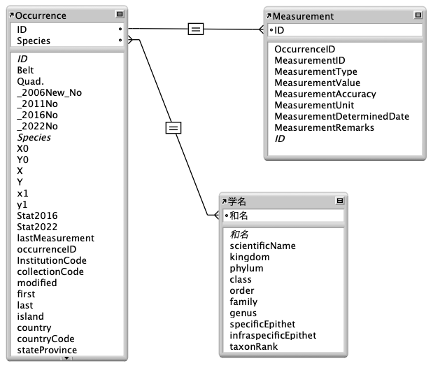

## データ処理の流れ

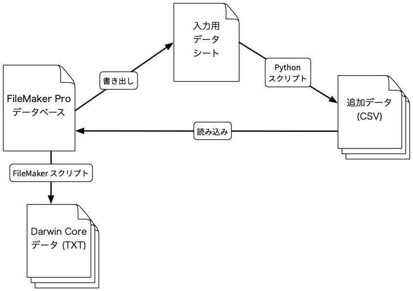

## Darwin Core Archiveの構造

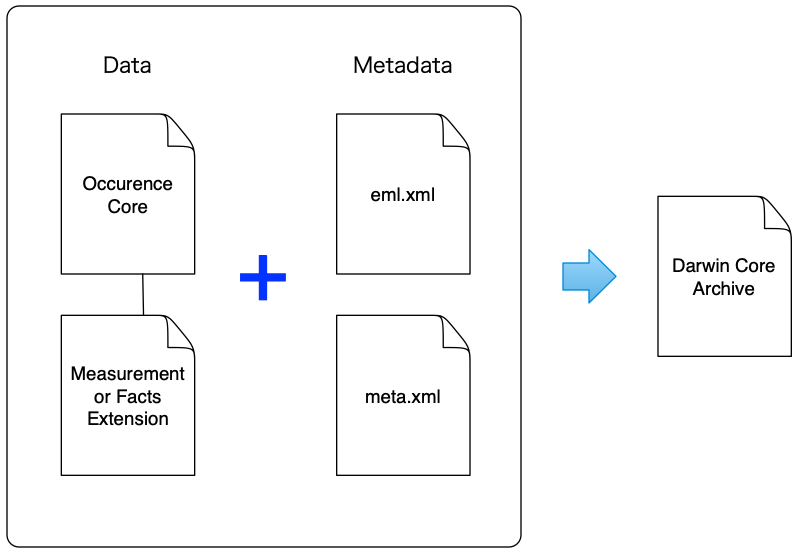

## メタデータ

- eml.xml
  - Ecological Metadata Language (EML) により記述されたメタデータ
    - データの概要、ライセンス、連絡先など
- meta.xml
  - データ構造の定義